# Written assignment 05

Farnoosh Koleini

2022-11-19

# Assignment Goal

The overarching goal of this assignment is to deepen your understanding of continuous probability distributions.

# Instructions

Please type your response to a question right below the question text. Compile this document to generate PDF output. Upload your PDF document to MS Teams. In the preamble above, change `V.N. Gudivada` to your name.

# Questions

## PMF and Variance

Let $X \sim U(0,3)$. Let $Y= \lfloor 2 X \rfloor - \lceil X \rceil$

1. Find $f_Y(y)$

**Solution**:

We need to find the probability density function for y. We learned this concept in depth in chapter 7. It is easy to work with cumulative distribution functions. We will find it using pdf strategy. We differentiate the cumulative distribution function to get the probability density function. $3 \times x = 1$, $x = \frac {1}{3}$ $f_{X}(x) = \frac {1}{3}$ when 0 < x < 3

2. Find $V[Y]$.

**Solution**:

We want to compute the variance of the new random variable,Y. $V[Y] = E[Y^2] - (E[X])^2$, How can we actually find the expected value of Y? $E[Y] = \sum y.f_{y}(y) = (-1). \frac {1}{6} + 0. \frac {1}{3} + 1. \frac {1}{3} + 2. \frac {1}{6} = \frac {1}{2}$, Also we can calculate the expected value of $Y^2$ which is $E[Y^2] = \sum y^2 f_y(y) = 1. \frac {1}{6} + 0. \frac{1}{6} + 1. \frac{1}{3} +4.\frac {1}{6} = \frac {7}{6}$ So now we are ready to find the variance of Y which is $V[Y] = E[Y^2] - (E[X])^2 = \frac {7}{6} - (\frac {1}{2})^2 = \frac {7}{6} - \frac {1}{4} = \frac {11}{12}$

$\blacksquare$

## Function of a random variable

Consider a circle with a random radius $R \sim U(0,5)$. What is the probability that the area of the circle is greater than twice the circumference? Support your solution by conducting a Monte Carlo simulation experiment.

**Solution**:

What is the probability of the area of the circle with a random radius $R \sim U(0,5)$. There is a uniform distribution between 0 and 5 and the area should be equal to one. If the height is $\frac {1}{5}$ the area behind the rectangular would be 1. The probability density of area would be: $f_{R}(r) = \frac {1}{5}$, when 0 < r < 5. We need to find the probability where the area is a circle $P(\pi R^2 > 2.2\pi .R) = P(R > 4) = \int_4^5 \frac {1}{5} d_r = \frac {1}{5} [r]_4^5 = \frac {1}{5}$

```r
numTrials <- 1000000
r <- runif(numTrials, 0,5)

# area vector of size numTrials
area <- pi*r^2

# circumference vector of size numTrials
circumference <- 2*pi*r

# area > 2 * circumference evaluates to TRUE (1)/FALSE(0) for each
# pair of values from the area and circumference vectors
mean (area > 2 * circumference)
```

```
## [1] 0.20034
```

```r
# cat(sprintf("Fraction of the circles in which the area is greater than twice the circumference is: %f\n", result))
```

There is an area from 1 to 1000000 which stores all of these values. and each values of the circum of each value from 1 to 1000000. For the first circle which randomly generate is this area is a storage for that. Now what we do make this expression, $area > 2 \times circumference$ It is going to be a Boolean expression and the result would be a Boolean. You can visualize this computation by creating. So if is 1, it means $True = 1$ and if it is 0, it means $False = 0$. Boolean vector is going to be set to 1, and 0. If we do some this vector. We count how 0 are there and then take the mean. So it happens 20 percent of the time.

$\blacksquare$

## Functions of random variables

Show that if $X \sim$ exponential $(\lambda)$, then $Y = \ln(X)$ has an **extreme value distribution** with CDF:

$$\mathbb{F}_Y(y)=1-e^{-\lambda e^y}, \quad-\infty<y<\infty$$

**Solution**:

We have a new random variable which is $y$. This new random variable $y$ is a function with rate parameter $\lambda$ and the question says the cumulative distribution function. So show that the cumulative distribution function $y$ is given by this equation. We have another random variable y, and CDF would be $F_{Y}(y) = 1 - e^{-\lambda. e^{y}}$ and support is from -infinity to +infinity. CDF of an exponential distribution function, $F_{X}(x) = 0$ when $x \leq 0$ and $F_{X}(x) = 1-e^{-\lambda x}$ when $x > 0$. Now if we can find Y, $F_Y(y) = P(Y \leq y)$. If we want to write Y, $P(\ln(x) \leq y) = F_X(e^y)$ You should take the natural log from the left hand side. If you look at the CDF of X it is $1-e^{-\lambda x} = 1-e^{-\lambda e^y}$ and support here is when Y is between - infinity to +infinity.

$\blacksquare$

## Exponential distribution mixtures

A box contains the following six flashlights.

- There is one Type 1 flashlight with an exponential(1) lifetime.
- There are two Type 2 flashlights with exponential(1/2) lifetimes.
- There are three Type 3 flashlight with exponential(1/3) lifetimes.

You select a flashlight at random from the box.

1. What is the probability that the flashlight selected lasts more than 4 hours?

**Solution**:

$P(X>4) = 1 - P(X \leq 4) = 1 - F_X(4)= \frac {1}{6} (1 - e^{-4}) + \frac {1}{3} (1 - e^{-2}) + \frac {1}{2} (1 - e^{\frac{-4}{3}})$ This value is approximately 0.1800.

2. Given that the flashlight lasts more than 4 hours, what is the probability that it is a Type 3 flashlight?

**Solution**:

What is the probability that it is the type three flashlight. We have three types of flash lights 1, 2, 3.  
Because we have a box, there is one of type 1 and three of type 3 and two of the type 2. We translate this to more formal expression. What is the probability that it is type 3 flash light. $P(J=3 | X> 4)$, $\frac{P(J=3 and X>4)}{P(X>4)}$, when we have a joint probability like this, this can be written as using base theorem. The nominator is $P(X>4|J=3).P(J=3)$ and the denominator would be $P(X>4|J=1) + P(X>4|J=2).P(J=2)+P(X>4|J=3).P(J=3)$,

First we will calculate the nominator which is $e^{-4/3}\times 0.5$,

Then we calculate the denominator which is $e^4 \times 1/6 + e^{-2} \times 1/3 + e^{-4/3} \times 0.5 = \frac{0.1318}{0.18} = 0.7324$

$\blacksquare$

## Normal distribution percentiles

Find the 99th percentile of a normal random variable with $\mu=8$ and $\sigma^2=9$. If $X \sim N(8,9)$, we want to find a constant $c$ satisfying $P(X<c)=0.99$

**Solution**:

We want to find a constant C in such that the probability of random variable X is less than C. If we have a normal distribution, $\mu$ is less than small c. We are going to subtract mean which equals 0.99. We are going to divide it by standard deviation. and the value would be again 0.99. Now what we have here is the probability of normalized Z is less than or equal to $\frac {c-8}{3}$ and again it equals 0.99. We need to find z values corresponds to 0.99. This value $\frac {c-8}{3} = 2.33$ So $C = 14.97$.

Also you do not need to standardizing the random variable.

In `R`, this can be found using the following command:

```r
qnorm (0.99, 8, 3)
```

```
## [1] 14.97904
```

$\blacksquare$

## Moment Generating Functions

Show that the population skewness and kurtosis of a $N\left(\mu, \sigma^2\right)$ random variable are 0 and 3, respectively.

**Solution**:

Here we are dealing with moment generating function and we are going to compute the moments. Take the moment generating function for normal random variable which we have already drive. We take the first derivative and then use that for third and fourth moments.

$\frac{d}{dx}(e^x) = e^x$,$m(t) = e^{\mu t + \frac {\sigma^2 t^2}{2}}$, $m'(t) = (e^{\mu t + \frac {\sigma^2 t^2}{2}})(\mu + \frac{\sigma^2 xt}{2}) = e^{\mu t + \frac {\sigma^2 t^2}{2}} (\mu + \sigma^2t) = m(t) (\mu + \sigma^2 t)$

Now if we want to find the second moment, it will be like:

$m''(t) = m(t)\sigma^2 + m(t)(\mu + \sigma^2t)^2$

Then third moment will be:

$m'''(t) = m(t) \sigma^2 (\mu + \sigma^2 t) + 2m (t)\sigma^2 = 3m(t)\sigma^2(\mu + \sigma^2 t) + m(t)(\mu +\sigma^2t)^3$

And lastly the forth moment would be:

$m''''(t)= 3m(t)\sigma^4 + 3(\mu +\sigma^2t)^2\sigma^2m(t)+m(t)(\mu + \sigma^2t)^4 + 3m(t)(\mu + \sigma^2t)^2\sigma^2$,

$m''''(t)= 3m(t)\sigma^4 + 6m(t)(\mu + \sigma^2t)^2 \sigma^2 + m(t)(\mu + \sigma^2t)^4$,

So then if we want to calculate these moments. $m'(0)=\mu$, $m''(0)=\sigma^2 + \mu^2$, $m'''(0)= 3\sigma^2\mu +\mu^3$, $m''''(0)= 3\sigma^4 + 6\mu^2\sigma^2 + \mu^4$.

Skewness:

$E[(\frac{X-\mu}{\sigma})] = \frac{1}{3}[E[X^3] - 3E[X^2]\mu + 2\mu^3]= \frac{1}{\sigma^3}[E[3\sigma^2\mu + \mu^3] - 3E[\sigma^2 + \mu^2] + 3\mu^3]= 0$

Kurtosis:

$E[(\frac {X-\mu}{\sigma})^4]= \frac{1}{\sigma^4}[E[X^4] - 4E[X^3]\mu + 6E[X^2]\mu^2 - 3\mu^4]=3$

$\blacksquare$

## R expressions and drawing PMFs/PDFs

Write the `R` statements and associated output to compute the following quantities. Draw a graph of the PMF or PDF illustrating the quantity being computed.

1. The 90th percentile of a $U(0,20)$ random variable.

**Solution**:

We have a uniform distribution from 0 to 20. We wan to find a value which 90 percent of the values are behind of that, it means it includes the 90 percent of the values and just skipping that 10 percent. We can easily use a simple code:

```r
qunif(0.9, 0, 20)
```

```
## [1] 18
```

2. The 20th percentile of a $N(0,1)$ random variable.

**Solution**:

We want 20th percentile or standard normal distribution. This one is quite simple if we want to calculate them with R. And here because it is normal we don’t need to specify the values for mean and variance.

```r
qnorm(0.20)
```

```
## [1] -0.8416212
```

3. The interquartile range of a $N(5,9)$ random variable.

**Solution**:

In this question we need to specify the mean value and variance which are 5 and 9. First we need to know what is the interquartile range. There are first, second, third, and fourth quartile. The interquartile (IQR) is from the first to third one, the two sections in between. So again there is a simple code here.

Also we can compute normal distribution 0.75 quartile. So after calculation these two values, we need to find the interquartile which is between of these two.

```r
X1<- qnorm(0.25,5,3)
X2<- qnorm(0.75,5,3)
result <- X2-X1
result
```

```
## [1] 4.046939
```

4. The interquartile range of a binomial(10,0.4) random variable.

**Solution**:

Here we need to find the IOR for random variable. The number of trials are 10 and the probability of success is 0.4.

```r
X1<- qbinom(0.25, 10, 0.4)
X2<- qbinom(0.75, 10, 0.4)
result2<- X2-X1
result2
```

```
## [1] 2
```

$\blacksquare$

## Normal random variable

Let $X$ be normally distributed with population mean $\mu=2$ and population variance $\sigma^2=9$.

1. What is $\mathbb{P}(X<8)$?

**Solution**:

There are two ways to answer this question. We have a normal distribution here. We want to find the density. There is a simple code in R we can find it.

We’re going to subtract mean from both sides of the equality. $P(\frac {X-2}{3} < \frac {8-2}{3})$, $P(Z<2)$.

```r
pnorm(8,2,3)
```

```
## [1] 0.9772499
```

```r
pnorm(2)
```

```
## [1] 0.9772499
```

2. What is $\mathbb{P}(4<X<8)$?

**Solution**:

This is a normal distribution, mean is 2. We want the probability when X is between 4 and 8. We can just easily use R code here.

```r
X2<- pnorm(8,2,3)
X1<- pnorm(4,2,3)
r<- X2-X1
r
```

```
## [1] 0.2297424
```

There is a second way:

$P(4 < X < 8)$ $P(4-2 < X-2 < 8-2)$, $P(\frac{4-2}{3} < \frac{X-2}{3} < \frac{8-2}{3})$ $P(\frac{2}{3} < Z < 2)$

```r
pnorm(2) - pnorm(2/3)
```

```
## [1] 0.2297424
```

3. What is $\mathbb{P}(X>10)$?

**Solution**:

We can use a complementary strategy here, $P(X>10) = 1- P(X\leq 10)$,

```r
1-pnorm(10,2,3)
```

```
## [1] 0.003830381
```

The second way:

$P(X>10) = P(\frac{X-2}{3} > \frac{10-2}{3})$, $P(Z>\frac{8}{3}) = 1 - P(Z < \frac{8}{3})$

```r
1-pnorm(8/3)
```

```
## [1] 0.003830381
```

4. Find a constant $a$ such that $\mathbb{P}(X<a)=0.95$.

**Solution**:

We need to find some point in a such that the area value is less than a value. We can use the quantile function:

```r
qnorm(0.95,2,3)
```

```
## [1] 6.934561
```

5. Find a constant $b$ such that $\mathbb{P}(-b<X<b)=0.95$.

**Solution**:

We want to find b in a way that the area between b and -b.

$P(-b < X < b)$, $P(\frac{-b-2}{3} < \frac{X-2}{3} < \frac{b-2}{3})$ $P(\frac{-b-2}{3} < Z < \frac{b-2}{3})$

```r
b <- seq(6, 8, by=0.1)
# b
pnorm(b, 2, 3) - pnorm(-b, 2, 3)
```

```
##  [1] 0.9049584 0.9106681 0.9161085 0.9212871 0.9262115 0.9308895 0.9353290
##  [8] 0.9395379 0.9435240 0.9472953 0.9508597 0.9542252 0.9573995 0.9603904
## [15] 0.9632055 0.9658525 0.9683388 0.9706717 0.9728583 0.9749057 0.9768208
```

The value of $b$ can be calculated more efficiently in $\mathrm{R}$ by using the uniroot function, which numerically solves equations. The `R` statements to solve this problem are given below.

```r
f= function(x)
  pnorm(x, 2, 3) - pnorm(-x, 2, 3) - 0.95
uniroot(f, c(-10,10))$root
```

```
## [1] 6.975362
```

6. If six random variables with this probability distribution are observed, what is the probability that exactly four of them are less than eight?

**Solution**:

This one is a binomial distribution. We have 6 random variable. The probability distribution when the probability that exactly four of them are less than eight.

$P(X < 8) = 0.9772$, ${6}\choose{4}$ $(0.9772)^4 (1-0.9772)^{6-4} = 0.007081$.

$\blacksquare$

## Various probability distributions

A box contains 50 low-wattage light bulbs and 50 high-wattage light bulbs.

1. If a random sample of ten light bulbs is taken without replacement from the box, what is the exact probability that at least four of each type of light bulb is in the sample?

**Solution**:

This reminds me a high-per geometric distribution. First we can find the exact solutions then the approxiamte answer for them. Sampling is performed without replacement. $m = 50$, $N= 100$ and $n=10$.

$f(x) = \frac{{50 \choose x}{50 \choose 10-x}}{{100 \choose 10}}$ and the sample size is x = 0,1,2,3,…,10.

$\sum_4^6 \frac{{50 \choose x}{50 \choose 10-x}}{ {100 \choose 10}} = 0.6822$

2. As an approximation to the calculation from part (a), assume that the random sampling is performed with replacement. What is the exact probability that at least four of each type of light bulb is in a random sample drawn with replacement from the box?

**Solution**:

It is like flipping the coin. $n=10$ The probability of the low-w would be 50.

$f(x) = {10 \choose x} (\frac{1}{2})^x (1 - \frac{1}{2})^{10-x}$, when $4 \leq X \leq 6$,

$\sum_4^6 {10 \choose x} (\frac{1}{2})^x (1 - \frac{1}{2})^{10-x} = 0.65625$

3. Using the Poisson approximation to the binomial distribution, approximate the solution to part (b).

**Solution**:

$\lambda = np = 10. \frac{1}{2} = 5$,

$\sum_4^6\frac {5^x. e^{-5}}{x!} = 0.4972$

4. The shape of the probability mass function of the binomial distribution approaches that of the normal distribution for large values of $n$. The approximation works best for $p$ values near $p=1 / 2$. Using the normal approximation to the binomial distribution, approximate the solution to part (b). **Hint**: In order to use a continuous distribution (the normal distribution) to approximate a discrete distribution (the binomial distribution), use a continuity correction in computing the approximate probability.

**Solution**:

$\mu = np = 10\times 0.5 = 5$, $\sigma^2 = np(1 - p) = 10 \times 0.5 (1-0.5) = \frac{5}{2}$ $N(5, \frac {5}{2})$, $f(x) = \frac {1}{\sqrt {5\pi}}\times e^{\frac {(x+5)^2 }{5}}$, for support, x between -infinity and +infinity. $P(4 \leq X \leq 6) = \int_{3.5}^{6.5} \frac {1}{\sqrt {5\pi}}\times e^{\frac {(x+5)^2 }{5}} dx = 0.6572$

$\blacksquare$

## Probability expressions and their plots

For each probability below, give an expression and carefully plot (that is, use a computer or carefully plot by hand) on a single set of axes.

1. $P(\mu-k \sigma<X<\mu+k \sigma)$ when $X \sim N\left(\mu, \sigma^2\right)$ for $0 \leq k \leq 4$.

**Solution**:

In all cases what we have is $0 \leq k \leq 4$, and what we are tying to compute is $P(\mu - k\sigma \leq X \leq \mu + k\sigma)$ when $X \sim N\left(\mu, \sigma^2\right)$. We can convert it into standard distribution. $P(\frac {\mu - k\sigma -\mu}{\sigma} \leq \frac{X- \mu}{\sigma} \leq \frac{\mu + k\sigma - \mu}{\sigma}) = P(-k\leq Z\leq k)$ We can choose a particular value for k so then we can use for example in this case. $pnorm(k) - pnorm(-k)$

2. $\mathbb{P}(\mu-k \sigma<X<\mu+k \sigma)$ when $X$ is exponentially distributed with population mean 2 for $0 \leq k \leq 4$.

**Solution**:

We’re going to calculate $\mathbb{P}(\mu-k \sigma<X<\mu+k \sigma)$. In this case we’re gonna use exponential distribution for value $0 \leq k\leq 4$.

$\int_{0}^{4} \frac {1}{2} e^{\frac{-x}{2}} + \int_{4}^{2+2k}\frac {1}{2} e^{\frac{-x}{2}}$,

3. $P(\mu-k \sigma<X<\mu+k \sigma)$ when $X$ has a Poisson distribution with population mean 4 for $0 \leq k \leq 4$

**Solution**:

If you recall poisson distribution, the density of the poisson distribution would be $f(x) = \frac {\lambda ^x e^{-\lambda}}{x!}$

$P(\mu-k \sigma<X<\mu+k \sigma) = P(4-2k < X< 4+2k)$, $\sum_{5-2k}^{3+2k} \frac {4 ^x e^{-4}}{x!}$ when $0 < k \leq 2$. and there is another function $\sum_{0}^{3+2k} {4 ^x e^{-4}}{x!}$, when $k>2$.

4. The lower bound on $P(\mu-k \sigma<X<\mu+k \sigma)$ provided by Chebyshev’s inequality for $1 \leq k \leq 4$

**Solution**:

$P(\mu-k \sigma<X<\mu+k \sigma) = 1 - \frac {1}{k^2}$,

The plots of all of these functions:

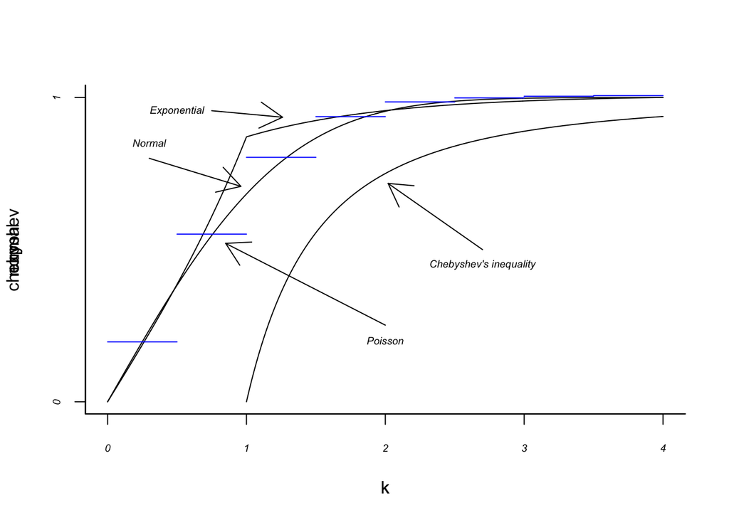

```r
k <- seq(0,4, by <- 0.01)

normal <-  pnorm(k) - pnorm(-k)

plot(k, normal, xlim = c(0,4), ylim = c(0,1), type = "l", bty = "l", xaxp = c(0,4,4), yaxp = c(0,1,1), font.axis = 3, cex.axis = 0.6)

arrows(0.3,0.8, k[100]-0.03, normal[100] + 0.03, code = 2)
text (0.3,0.85, "Normal", font = 3, cex = 0.6)

exponential =  function (kvalue){
if (kvalue <1)
    exp(-(1 - kvalue)) - exp(-(1 + kvalue))
else
    1 - exp(- (1+ kvalue))
}

expon <- rep(0,401)

for (i in 1: 401)
 expon[i] <-  exponential(k[i])

par(new = TRUE, yaxt = "n", xaxt = "n")

plot (k, expon, xlim = c(0,4), y1im = c(0,1), type = "l", bty = "l", xaxp = c(0,4,4), yaxp = c(0,1,1), font.axis = 3, cex.axis = 0.6)
arrows(0.75, 0.95, k[130]-0.03, expon [130]+0.03, code = 2)

text(0.5, 0.95, "Exponential", font = 3, cex = 0.6)

pssn =  function(kvalue){
    if (kvalue <= 2 )
        limits = c(floor(5 - 2 * kvalue):ceiling(3 + 2 * kvalue))
    else
        limits = c(0:ceiling(3 + 2 * kvalue))

    sum(dpois(limits, 4))
}

for (i in 1: 8)
    segments((i-1)/2, pssn(i/2), i/2, pssn(i/2), col = "blue")

arrows(2, 0.25, 0.85, pssn(0.85) - 0.03, code=2)

text (2, 0.2, "Poisson", font = 3, cex = 0.6)

k <- seq(1, 4, by = 0.01)

chebyshev <- 1 - 1/k^2

par(new = TRUE, yaxt = "n", xaxt = "n")

plot(k, chebyshev, xlim = c(0,4), ylim = c(0,1), type = "l", bty = "l", xaxp = c(0,4,4), yaxp = c(0,1,1), font.axis = 3, cex.axis = 0.6)

arrows(2.7, 0.5, k[100]+0.03, chebyshev[100] - 0.03, code = 2)

text(2.7, 0.45, "Chebyshev's inequality", font = 3, cex = 0.6)

text(4.35, -0.04, "k", font = 10, cex = 0.6)

text(-0.12, 1.10, "P", font = 10, cex = 0.6)
```